# How to use the R_introduction.pdf

## First, get the document from github

https://github.com/STATShunt/tia/blob/master/notes/R_introduction.pdf (click on the “download” button on the rhs)

For KLA201 KLA310 KLA439 you need to know at least how to doe each of the things from chapter 2.

## Start RStudio

And try to save your examples in an R script (in Rstudio go to File–>New File–>R Script).

## Practice on your own

``People have now-a-days got a strange opinion that everything should be taught by lectures. Now, I cannot see that lectures can do so much as reading the books from which the lectures are taken. I know nothing that can be best taught by lectures, except where experiments are to be shewn. You may teach chemistry by lectures:– You might teach the making of shoes by lectures!’’, attributed to Samuel Johnson by his biographer, Boswell.

### 2.5 Calculation Order

Use round brackets to control calculation order.

```r
(1+2*3)
```

```
## [1] 7
```

```r
(1+2)*3
```

```
## [1] 9
```

Now try something you make up for yourself …

```r
1:10 # a sequence
```

```
##  [1]  1  2  3  4  5  6  7  8  9 10
```

```r
(1:10)*3
```

```
##  [1]  3  6  9 12 15 18 21 24 27 30
```

### 2.7 Functions

Functions do stuff with data (mainly).

```r
c(1:10,5,99) # the function c joins things together
```

```
##  [1]  1  2  3  4  5  6  7  8  9 10  5 99
```

```r
sum(1:6) # add things up
```

```
## [1] 21
```

```r
sum(1:6)/6 # an average
```

```
## [1] 3.5
```

```r
mean(1:6) # another average
```

```
## [1] 3.5
```

Functions can be nested (really important)

```r
sum(c(1:10,5,99))
```

```
## [1] 159
```

```r
length(c(1:10,5,99))  # count the number of elements
```

```
## [1] 12
```

```r
mean(c(1:10,5,99))
```

```
## [1] 13.25
```

```r
sum(c(1:10,5,99))/length(c(1:10,5,99))
```

```
## [1] 13.25
```

### 2.8 Random Numbers

Easily generate lots of numbers from a known distribution. Not really random (they come from “unstable looking” algorithms).

```r
rnorm(10) # ten normal (mean 0, sd 1) random numbers
```

```
##  [1]  0.2141065 -0.3479465 -1.6932332 -0.4145313 -0.5517815  1.6798882
##  [7] -0.2743682 -0.5804797 -0.1792467 -0.2220824
```

```r
rnorm(n=10,mean=0,sd=1) # same thing
```

```
##  [1]  1.25685192 -2.14331872 -0.39091238 -2.05096507 -0.04668332 -0.16628418
##  [7]  0.09736577  1.41262219 -0.54213963 -1.01924005
```

```r
length(rnorm(10)) # ten numbers
```

```
## [1] 10
```

```r
rnorm(10);rnorm(10);rnorm(10) #different every time
```

```
##  [1] -1.22596750 -0.52230555 -1.12710348  3.14540057  0.21963118  1.87063427
##  [7]  2.47161530  0.01433345  1.39596825 -0.68887705
```

```
##  [1] -1.0398544  0.3508693 -1.0528472 -0.4663572  0.2948528 -0.7405849
##  [7]  0.1052051 -0.7966593  0.7950895  1.2615045
```

```
##  [1]  0.986254973  0.382047508 -2.138464480 -2.466108341 -0.387526428
##  [6] -0.009084288  0.567395235  0.635669172 -0.272748477 -0.981517453
```

Visualize the distribution

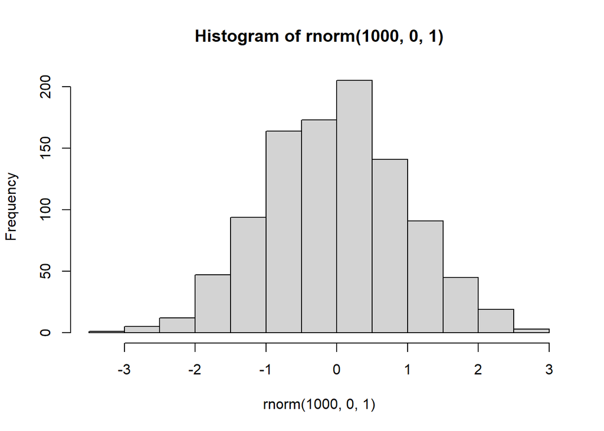

```r
hist(rnorm(1000,0,1))
```

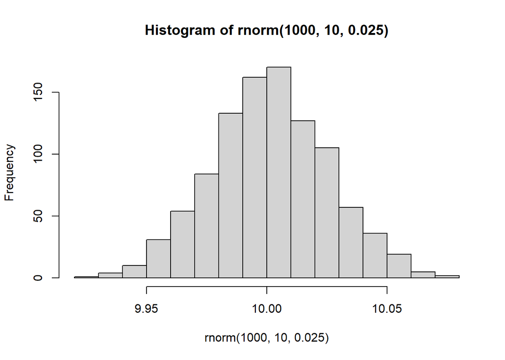

```r
hist(rnorm(1000,10,.025))
```

### 2.20 Variables

Start saving things within variables (to refer back to and operate on …)

```r
x<-rnorm(10)  #ten random numbers
x
```

```
##  [1] -1.03185788  1.22526385  0.02517603 -1.83762073  0.70546890 -0.35121417
##  [7]  0.28464351 -1.31532842  0.27827479 -1.15495211
```

### 2.16 Logical Data Types

Evaluating and using true and false.

```r
TRUE
```

```
## [1] TRUE
```

```r
TRUE+2  # turns TRUE into 1
```

```
## [1] 3
```

```r
FALSE+2 # turns FALSE into 0
```

```
## [1] 2
```

Now try generating true and false by evaluating expressions. See section 7.2 for more.

```r
(2+2)==4  # syntax for equality is "double equals"
```

```
## [1] TRUE
```

```r
set.seed(99)
x<-rnorm(10)
x
```

```
##  [1]  0.2139625  0.4796581  0.0878287  0.4438585 -0.3628379  0.1226740
##  [7] -0.8638452  0.4896243 -0.3641169 -1.2942420
```

```r
x>0
```

```
##  [1]  TRUE  TRUE  TRUE  TRUE FALSE  TRUE FALSE  TRUE FALSE FALSE
```

```r
x[1:3]  # pull out pieces ("elements") with square brackets (see Section 2.26 for example)
```

```
## [1] 0.2139625 0.4796581 0.0878287
```

```r
x[c(1,5)] # pull out elements using specific index values (the order in which elements occur)
```

```
## [1]  0.2139625 -0.3628379
```

```r
x[x>0] # pull out elements with a vector of logical values (TRUE gets returned and FALSE not)
```

```
## [1] 0.2139625 0.4796581 0.0878287 0.4438585 0.1226740 0.4896243
```